# Reproducible Research: Course Project 1

## Loading and preprocessing the data

Here I read the data from a CSV file into R.

```r
data <- read.csv("activity.csv")
clean_data <- data[!is.na(data$steps), ]
library(dplyr)
library(lattice)
```

## What is mean total number of steps taken per day?

Here I calculate the total number of steps per day.

```r
group_by_date <- group_by(clean_data, date)
table_by_date <- summarize(group_by_date, sum(steps))
names(table_by_date)[2] <- "steps"
```

Here I create a histogram showing the number of steps taken each day.

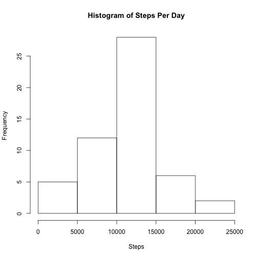

```r
hist(table_by_date$steps, xlab = "Steps", main = "Histogram of Steps Per Day")
```

Here I calculate the mean and median of the total number of steps taken per day.

```r
m_m <- data.frame()
m_m[1,1] <- mean(table_by_date$steps)
m_m[1,2] <- median(table_by_date$steps)
names(m_m) <- c("Mean", "Median")
print(m_m)
```

```
##       Mean Median
## 1 10766.19  10765
```

## What is the average daily activity pattern?

Here I make a time series plot of the average number of steps taken across the 5-minute intervals.

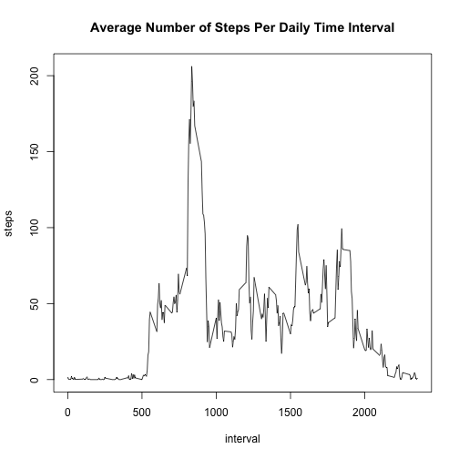

```r
group_by_interval <- group_by(clean_data, interval)
table_by_interval <- summarize(group_by_interval, mean(steps))
names(table_by_interval)[2] <- "steps"
with(table_by_interval, plot(interval, steps, type = "l",
                             main = "Average Number of Steps Per Daily Time Interval"))
```

Here I calculate the interval with the highest average number of steps.

```r
max_interval <- table_by_interval[table_by_interval$steps == max(table_by_interval$steps), "interval"]
print(max_interval[[1]])
```

```
## [1] 835
```

## Imputing Missing Values

Here I calculate the total number of missing values in the data set.

```r
num_nas <- sum(is.na(data))
print(num_nas)
```

```
## [1] 2304
```

Here I impute the missing values with the average interval value.

```r
imputed_data <- data
for (i in 1:length(imputed_data$steps)) {
        if (is.na(imputed_data$steps[i])==TRUE) {
                index <- table_by_interval$interval == imputed_data$interval[i]
                new_val <- table_by_interval[index, ]$steps
                imputed_data$steps[i] <- new_val
        }
}
```

Here I create a histogram showing the number of steps taken each day with imputed values.

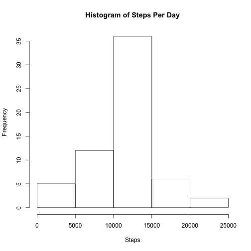

```r
group_by_date_i <- group_by(imputed_data, date)
table_by_date_i <- summarize(group_by_date_i, sum(steps))
names(table_by_date_i)[2] <- "steps"
hist(table_by_date_i$steps, xlab = "Steps", main = "Histogram of Steps Per Day")
```

Here I calculate the mean and median of the total number of steps taken per day with imputed values.

```r
m_m_i <- data.frame()
m_m_i[1,1] <- mean(table_by_date_i$steps)
m_m_i[1,2] <- median(table_by_date_i$steps)
names(m_m_i) <- c("Mean", "Median")
print(m_m_i)
```

```
##       Mean   Median
## 1 10766.19 10766.19
```

## Are there differences in activity patterns between weekdays and weekends?

Here I create a new factor variable defining the date as a weekday or weekend.

```r
clean_data$date <- as.Date(clean_data$date)
clean_data <- mutate(clean_data, ifelse(weekdays(date) %in% c("Saturday","Sunday"), "Weekend", "Weekday"))
names(clean_data)[4] <- "Day_Type"
clean_data$Day_Type <- as.factor(clean_data$Day_Type)
```

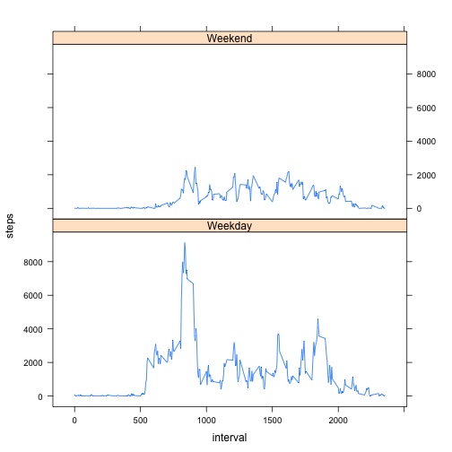

```r
clean_data_g <- group_by(clean_data, interval, Day_Type)
clean_data_sum <- summarize(clean_data_g, sum(steps))
names(clean_data_sum)[3] <- "steps"
with(clean_data_sum, xyplot(steps ~ interval | Day_Type, type = "l", layout = c(1,2)))
```